# Proyecto Final Econometría

Melissa Arizoca Longoria

2026-03-18

#Este script tiene como objetivo analizar el comportamiento de distintas acciones financieras mediante la aplicación de modelos de regresión lineal y técnicas de series de tiempo. Se estudian relaciones entre activos de los sectores bancario, tecnológico y energético, incluyendo empresas como JPM, BAC, CITI, WFC, SAN, MS, AMAT, LRCX, TSM, NVIDIA, STLA, XOM, VLO y SHEL.

#El análisis se realiza utilizando rendimientos logarítmicos y distintas frecuencias de datos, con el fin de evaluar la dinámica entre variables y la estabilidad de los modelos. Asimismo, se incorporan pruebas econométricas y herramientas de visualización para validar los supuestos del modelo y apoyar la interpretación de los resultados.

#Paso 1 : Cargar librerías

```r
packages <- c("readxl", "tidyverse", "lubridate", "car", "lmtest", "sandwich", "corrplot")

installed <- packages %in% installed.packages()[,"Package"]

if(any(!installed)){
  install.packages(packages[!installed])
}

lapply(packages, library, character.only = TRUE)
```

[output not shown]

#Paso 2 : Cargar archivos descargados de Refinitiv

```r
process_data <- function(files, names, date_format = "datetime") {

  data_list <- map2(files, names, function(file, name){

    df <- read_excel(file)

    df <- df %>%
      select(`Exchange Date`, Close) %>%
      rename(Date = `Exchange Date`,
             Price = Close) %>%
      mutate(
        Date = if(date_format == "datetime") as.POSIXct(Date) else as.Date(Date),
        Price = as.numeric(Price)
      ) %>%
      arrange(Date) %>%
      rename(!!name := Price)

    return(df)
  })

  merged <- reduce(data_list, full_join, by = "Date")

  returns <- merged %>%
    arrange(Date) %>%
    mutate(across(where(is.numeric),
                  ~ ifelse(.x > 0 & lag(.x) > 0,
                           log(.x / lag(.x)),
                           NA))) %>%
    drop_na()

  return(returns)
}
```

#PASO 3: ARCHIVOS (5 MIN)

```r
# Modelo bancario
bank_files_5 <- c("JPM5min030126_031526.xlsx",
                  "BAC5min030126_031526.xlsx",
                  "CITI5min030126_031526.xlsx",
                  "WFC5min030126_031526.xlsx",
                  "SAN5min030126_031526.xlsx",
                  "MS5min030126_031526.xlsx")

bank_names <- c("JPM","BAC","CITI","WFC","SAN","MS")

# Semiconductores
semi_files_5 <- c("AMAT5min030126_031526.xlsx",
                  "LRCX5min030126_031526.xlsx",
                  "TSM5min030126_031526.xlsx")

semi_names <- c("AMAT","LRCX","TSM")

# Energía
energy_files_5 <- c("NVDA5min030126_031526.xlsx",
                    "STLA5min030126_031526.xlsx",
                    "XOM5min030126_031526.xlsx",
                    "VLO5min030126_031526.xlsx",
                    "SHEL5min030126_031526.xlsx")

energy_names <- c("NVDA","STLA","XOM","VLO","SHEL")
```

#PASO 4: GENERAR DATASETS (5 MIN)

```r
bank_5 <- process_data(bank_files_5, bank_names, "datetime")
head(bank_5)
```

```
## # A tibble: 6 × 7
##   Date                       JPM       BAC       CITI      WFC      SAN       MS
##   <dttm>                   <dbl>     <dbl>      <dbl>    <dbl>    <dbl>    <dbl>
## 1 2026-03-02 10:40:00 -0.000338   0         0          0        3.84e-3 -1.11e-3
## 2 2026-03-02 10:45:00 -0.00129   -0.00103  -0.00251    1.24e-4  0       -2.47e-4
## 3 2026-03-02 10:50:00  0.0000339 -0.000205  0.00149   -8.71e-4  0        1.85e-4
## 4 2026-03-02 10:55:00 -0.000440  -0.000410 -0.00130    6.23e-4 -2.69e-3 -1.42e-3
## 5 2026-03-02 11:30:00 -0.0000338  0.000616 -0.0000932 -1.12e-3 -2.31e-3  3.09e-4
## 6 2026-03-02 11:35:00  0.000406   0.00103   0.000838   1.25e-4  9.62e-4  5.56e-4
```

```r
summary(bank_5)
```

```
##       Date                          JPM                  BAC
##  Min.   :2026-03-02 10:40:00   Min.   :-7.080e-03   Min.   :-9.020e-03
##  1st Qu.:2026-03-04 14:56:15   1st Qu.:-1.333e-03   1st Qu.:-1.254e-03
##  Median :2026-03-09 12:57:30   Median :-5.841e-05   Median :-2.115e-06
##  Mean   :2026-03-08 06:13:28   Mean   :-5.439e-05   Mean   :-3.016e-05
##  3rd Qu.:2026-03-11 15:13:45   3rd Qu.: 1.114e-03   3rd Qu.: 1.242e-03
##  Max.   :2026-03-13 18:15:00   Max.   : 1.144e-02   Max.   : 1.210e-02
##       CITI                 WFC                  SAN
##  Min.   :-2.938e-02   Min.   :-0.0252252   Min.   :-1.028e-02
##  1st Qu.:-1.499e-03   1st Qu.:-0.0013189   1st Qu.:-1.420e-03
##  Median : 0.000e+00   Median :-0.0000696   Median :-1.038e-04
##  Mean   : 1.165e-05   Mean   :-0.0001087   Mean   :-9.846e-05
##  3rd Qu.: 1.618e-03   3rd Qu.: 0.0013209   3rd Qu.: 1.201e-03
##  Max.   : 2.658e-02   Max.   : 0.0142652   Max.   : 1.342e-02
##        MS
##  Min.   :-2.521e-02
##  1st Qu.:-1.389e-03
##  Median : 0.000e+00
##  Mean   : 4.695e-06
##  3rd Qu.: 1.533e-03
##  Max.   : 1.748e-02
```

```r
semi_5   <- process_data(semi_files_5, semi_names, "datetime")
head(semi_5)
```

```
## # A tibble: 6 × 4
##   Date                     AMAT       LRCX        TSM
##   <dttm>                  <dbl>      <dbl>      <dbl>
## 1 2026-03-02 09:10:00  0.00361   0.00671    0.00158
## 2 2026-03-02 09:15:00  0.000825 -0.000484  -0.0000273
## 3 2026-03-02 09:20:00  0.000137  0.00145    0.00134
## 4 2026-03-02 09:25:00 -0.00121  -0.0000879 -0.00172
## 5 2026-03-02 09:30:00 -0.00212  -0.000308   0.00245
## 6 2026-03-02 09:35:00  0.000358  0.00136    0.000163
```

```r
summary(semi_5)
```

```
##       Date                          AMAT                 LRCX
##  Min.   :2026-03-02 09:10:00   Min.   :-3.207e-02   Min.   :-3.803e-02
##  1st Qu.:2026-03-04 16:25:00   1st Qu.:-1.347e-03   1st Qu.:-1.491e-03
##  Median :2026-03-07 00:00:00   Median : 0.000e+00   Median : 0.000e+00
##  Mean   :2026-03-08 02:42:36   Mean   :-3.617e-05   Mean   :-3.639e-05
##  3rd Qu.:2026-03-11 13:55:00   3rd Qu.: 1.294e-03   3rd Qu.: 1.418e-03
##  Max.   :2026-03-14 00:00:00   Max.   : 2.950e-02   Max.   : 2.177e-02
##       TSM
##  Min.   :-2.996e-02
##  1st Qu.:-8.572e-04
##  Median :-2.704e-05
##  Mean   :-4.344e-05
##  3rd Qu.: 8.177e-04
##  Max.   : 1.653e-02
```

```r
energy_5 <- process_data(energy_files_5, energy_names, "datetime")
head(energy_5)
```

```
## # A tibble: 6 × 6
##   Date                     NVDA     STLA       XOM       VLO      SHEL
##   <dttm>                  <dbl>    <dbl>     <dbl>     <dbl>     <dbl>
## 1 2026-03-02 14:40:00  0.000302  0.00327 -0.00964  -0.0155   -0.00320
## 2 2026-03-02 14:45:00  0.00268  -0.00196  0.00441   0.00422  -0.000963
## 3 2026-03-02 14:50:00  0.00259  -0.00131 -0.00183  -0.00520  -0.00112
## 4 2026-03-02 14:55:00 -0.00303  -0.00460  0.00363   0.00328   0.00673
## 5 2026-03-02 15:00:00  0.00106  -0.00132 -0.00231   0.00896  -0.000798
## 6 2026-03-02 15:05:00  0.00150   0       -0.000354 -0.000895  0.00223
```

```r
summary(energy_5)
```

```
##       Date                          NVDA                 STLA
##  Min.   :2026-03-02 14:40:00   Min.   :-0.0072320   Min.   :-0.0087913
##  1st Qu.:2026-03-05 15:01:15   1st Qu.:-0.0011919   1st Qu.:-0.0021602
##  Median :2026-03-09 16:17:30   Median : 0.0002662   Median : 0.0000000
##  Mean   :2026-03-08 21:44:55   Mean   : 0.0001495   Mean   :-0.0002927
##  3rd Qu.:2026-03-11 16:33:45   3rd Qu.: 0.0015208   3rd Qu.: 0.0014509
##  Max.   :2026-03-13 16:30:00   Max.   : 0.0078101   Max.   : 0.0111567
##       XOM                  VLO                  SHEL
##  Min.   :-1.545e-02   Min.   :-1.904e-02   Min.   :-7.695e-03
##  1st Qu.:-1.148e-03   1st Qu.:-1.682e-03   1st Qu.:-8.111e-04
##  Median : 4.886e-05   Median : 6.292e-05   Median : 1.602e-04
##  Mean   :-2.500e-05   Mean   : 4.050e-05   Mean   : 7.018e-05
##  3rd Qu.: 1.460e-03   3rd Qu.: 2.149e-03   3rd Qu.: 1.098e-03
##  Max.   : 8.163e-03   Max.   : 1.546e-02   Max.   : 9.951e-03
```

#PASO 5: MODELOS (5 MIN)

```r
# Modelo 1: Bancario
model_bank_5 <- lm(JPM ~ BAC + CITI + WFC + SAN + MS, data = bank_5)

# Modelo 2: Semiconductores
model_semi_5 <- lm(AMAT ~ LRCX + TSM, data = semi_5)

# Modelo 3: Energía / Autos
model_energy_5 <- lm(NVDA ~ STLA + XOM + VLO + SHEL, data = energy_5)
```

#PASO 6: RESULTADOS

```r
summary(model_bank_5)
```

```
##
## Call:
## lm(formula = JPM ~ BAC + CITI + WFC + SAN + MS, data = bank_5)
##
## Residuals:
##        Min         1Q     Median         3Q        Max
## -0.0092386 -0.0008068 -0.0000381  0.0007635  0.0069976
##
## Coefficients:
##               Estimate Std. Error t value Pr(>|t|)
## (Intercept) -2.207e-05  6.854e-05  -0.322  0.74759
## BAC          2.538e-01  4.131e-02   6.144 1.52e-09 ***
## CITI         7.328e-02  2.599e-02   2.820  0.00497 **
## WFC          9.360e-02  2.962e-02   3.160  0.00166 **
## SAN          1.614e-01  3.306e-02   4.882 1.37e-06 ***
## MS           1.160e-01  2.752e-02   4.214 2.92e-05 ***
## ---
## Signif. codes:  0 '***' 0.001 '**' 0.01 '*' 0.05 '.' 0.1 ' ' 1
##
## Residual standard error: 0.001627 on 560 degrees of freedom
## Multiple R-squared:  0.4317, Adjusted R-squared:  0.4266
## F-statistic: 85.06 on 5 and 560 DF,  p-value: < 2.2e-16
```

```r
summary(model_semi_5)
```

```
##
## Call:
## lm(formula = AMAT ~ LRCX + TSM, data = semi_5)
##
## Residuals:
##        Min         1Q     Median         3Q        Max
## -0.0233564 -0.0009959 -0.0000086  0.0010220  0.0245183
##
## Coefficients:
##               Estimate Std. Error t value Pr(>|t|)
## (Intercept) -2.619e-06  5.487e-05  -0.048    0.962
## LRCX         3.769e-01  2.073e-02  18.178   <2e-16 ***
## TSM          4.566e-01  3.130e-02  14.588   <2e-16 ***
## ---
## Signif. codes:  0 '***' 0.001 '**' 0.01 '*' 0.05 '.' 0.1 ' ' 1
##
## Residual standard error: 0.002372 on 1866 degrees of freedom
## Multiple R-squared:  0.4128, Adjusted R-squared:  0.4122
## F-statistic: 655.9 on 2 and 1866 DF,  p-value: < 2.2e-16
```

```r
summary(model_energy_5)
```

```
##
## Call:
## lm(formula = NVDA ~ STLA + XOM + VLO + SHEL, data = energy_5)
##
## Residuals:
##       Min        1Q    Median        3Q       Max
## -0.006224 -0.001277 -0.000020  0.001334  0.006926
##
## Coefficients:
##               Estimate Std. Error t value Pr(>|t|)
## (Intercept)  0.0002312  0.0001240   1.864   0.0633 .
## STLA         0.2771824  0.0399205   6.943 2.53e-11 ***
## XOM          0.0446393  0.0615207   0.726   0.4687
## VLO         -0.0118640  0.0377568  -0.314   0.7536
## SHEL         0.0145220  0.0835789   0.174   0.8622
## ---
## Signif. codes:  0 '***' 0.001 '**' 0.01 '*' 0.05 '.' 0.1 ' ' 1
##
## Residual standard error: 0.002113 on 289 degrees of freedom
## Multiple R-squared:  0.1503, Adjusted R-squared:  0.1385
## F-statistic: 12.78 on 4 and 289 DF,  p-value: 1.364e-09
```

#PASO 7: DIAGNÓSTICOS COMPLETOS

#Modelo Bancario

```r
# Multicolinealidad
vif(model_bank_5)
```

```
##      BAC     CITI      WFC      SAN       MS
## 1.981164 1.649226 1.575553 1.313163 1.531478
```

```r
# Autocorrelación
durbinWatsonTest(model_bank_5)
```

```
##  lag Autocorrelation D-W Statistic p-value
##    1      -0.2361971      2.468776       0
##  Alternative hypothesis: rho != 0
```

```r
bgtest(model_bank_5)
```

```
##
##  Breusch-Godfrey test for serial correlation of order up to 1
##
## data:  model_bank_5
## LM test = 32.526, df = 1, p-value = 1.176e-08
```

```r
# Heterocedasticidad
bptest(model_bank_5)
```

```
##
##  studentized Breusch-Pagan test
##
## data:  model_bank_5
## BP = 23.358, df = 5, p-value = 0.0002883
```

```r
gqtest(model_bank_5)
```

```
##
##  Goldfeld-Quandt test
##
## data:  model_bank_5
## GQ = 0.83898, df1 = 277, df2 = 277, p-value = 0.9277
## alternative hypothesis: variance increases from segment 1 to 2
```

```r
# Errores robustos
coeftest(model_bank_5, vcov = vcovHC(model_bank_5, type = "HC1"))
```

```
##
## t test of coefficients:
##
##                Estimate  Std. Error t value  Pr(>|t|)
## (Intercept) -2.2067e-05  6.7884e-05 -0.3251  0.745254
## BAC          2.5381e-01  7.7715e-02  3.2659  0.001158 **
## CITI         7.3278e-02  3.8218e-02  1.9174  0.055699 .
## WFC          9.3600e-02  5.3407e-02  1.7526  0.080221 .
## SAN          1.6140e-01  4.0602e-02  3.9751 7.955e-05 ***
## MS           1.1599e-01  5.5561e-02  2.0877  0.037280 *
## ---
## Signif. codes:  0 '***' 0.001 '**' 0.01 '*' 0.05 '.' 0.1 ' ' 1
```

#Modelo Semiconductores

```r
vif(model_semi_5)
```

```
##     LRCX      TSM
## 1.532576 1.532576
```

```r
durbinWatsonTest(model_semi_5)
```

```
##  lag Autocorrelation D-W Statistic p-value
##    1      -0.3410266      2.681805       0
##  Alternative hypothesis: rho != 0
```

```r
bgtest(model_semi_5)
```

```
##
##  Breusch-Godfrey test for serial correlation of order up to 1
##
## data:  model_semi_5
## LM test = 220.5, df = 1, p-value < 2.2e-16
```

```r
bptest(model_semi_5)
```

```
##
##  studentized Breusch-Pagan test
##
## data:  model_semi_5
## BP = 0.46758, df = 2, p-value = 0.7915
```

```r
gqtest(model_semi_5)
```

```
##
##  Goldfeld-Quandt test
##
## data:  model_semi_5
## GQ = 0.78893, df1 = 932, df2 = 931, p-value = 0.9998
## alternative hypothesis: variance increases from segment 1 to 2
```

```r
coeftest(model_semi_5, vcov = vcovHC(model_semi_5, type = "HC1"))
```

```
##
## t test of coefficients:
##
##                Estimate  Std. Error t value  Pr(>|t|)
## (Intercept) -2.6191e-06  5.4893e-05 -0.0477     0.962
## LRCX         3.7690e-01  4.6491e-02  8.1070 9.294e-16 ***
## TSM          4.5656e-01  5.9062e-02  7.7303 1.742e-14 ***
## ---
## Signif. codes:  0 '***' 0.001 '**' 0.01 '*' 0.05 '.' 0.1 ' ' 1
```

#Modelo Energía

```r
vif(model_energy_5)
```

```
##     STLA      XOM      VLO     SHEL
## 1.033397 1.748270 1.379240 1.618785
```

```r
durbinWatsonTest(model_energy_5)
```

```
##  lag Autocorrelation D-W Statistic p-value
##    1     -0.03589326      2.071455    0.49
##  Alternative hypothesis: rho != 0
```

```r
bgtest(model_energy_5)
```

```
##
##  Breusch-Godfrey test for serial correlation of order up to 1
##
## data:  model_energy_5
## LM test = 0.39389, df = 1, p-value = 0.5303
```

```r
bptest(model_energy_5)
```

```
##
##  studentized Breusch-Pagan test
##
## data:  model_energy_5
## BP = 10.825, df = 4, p-value = 0.0286
```

```r
gqtest(model_energy_5)
```

```
##
##  Goldfeld-Quandt test
##
## data:  model_energy_5
## GQ = 0.75465, df1 = 142, df2 = 142, p-value = 0.9527
## alternative hypothesis: variance increases from segment 1 to 2
```

```r
coeftest(model_energy_5, vcov = vcovHC(model_energy_5, type = "HC1"))
```

```
##
## t test of coefficients:
##
##                Estimate  Std. Error t value  Pr(>|t|)
## (Intercept)  0.00023117  0.00012356  1.8709   0.06236 .
## STLA         0.27718240  0.04102536  6.7564 7.787e-11 ***
## XOM          0.04463933  0.07381335  0.6048   0.54581
## VLO         -0.01186401  0.04046773 -0.2932   0.76960
## SHEL         0.01452195  0.08710353  0.1667   0.86771
## ---
## Signif. codes:  0 '***' 0.001 '**' 0.01 '*' 0.05 '.' 0.1 ' ' 1
```

#PASO 8: GRÁFICAS

#Modelo Bancario

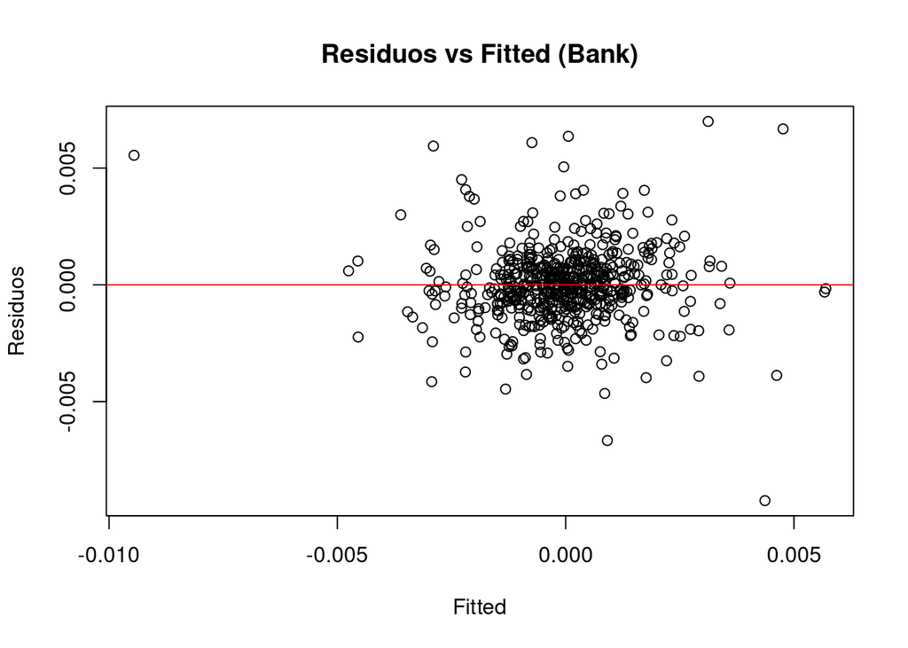

```r
# Residuos vs fitted
plot(fitted(model_bank_5), residuals(model_bank_5),
     main = "Residuos vs Fitted (Bank)",
     xlab = "Fitted", ylab = "Residuos")
abline(h = 0, col = "red")
```

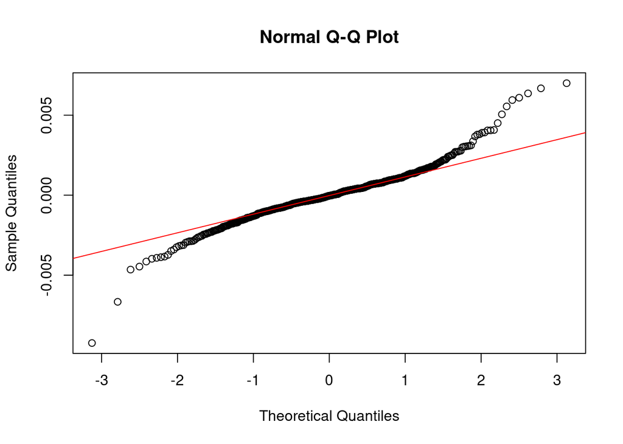

```r
# QQ plot
qqnorm(residuals(model_bank_5))
qqline(residuals(model_bank_5), col = "red")
```

#Modelo Semiconductores

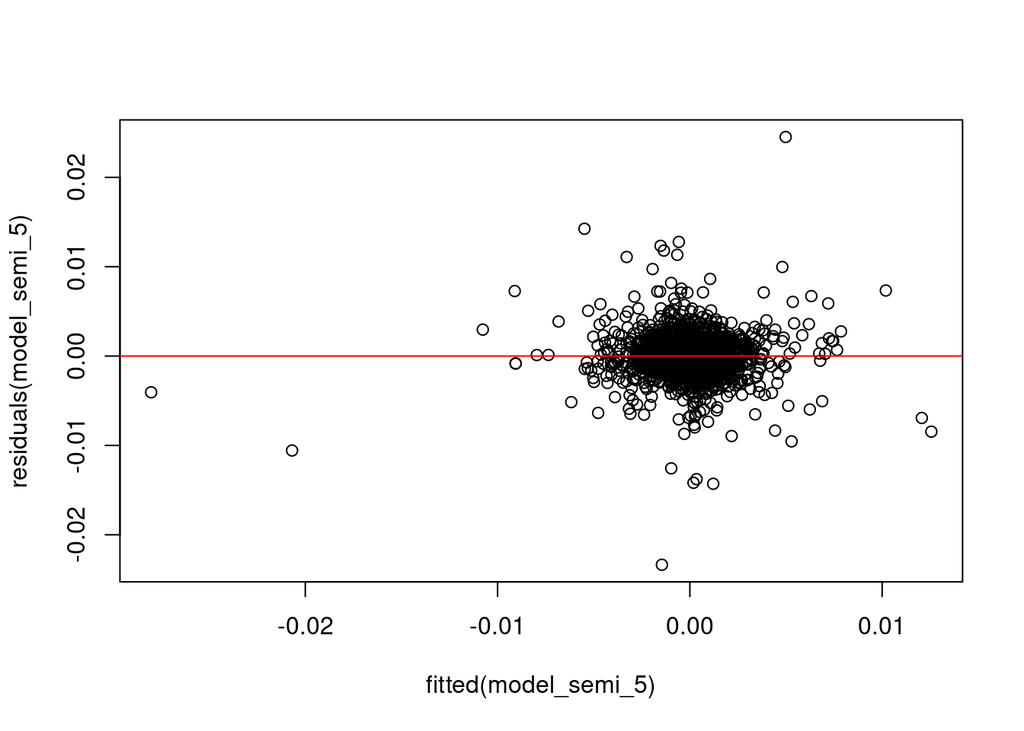

```r
plot(fitted(model_semi_5), residuals(model_semi_5))
abline(h = 0, col = "red")
```

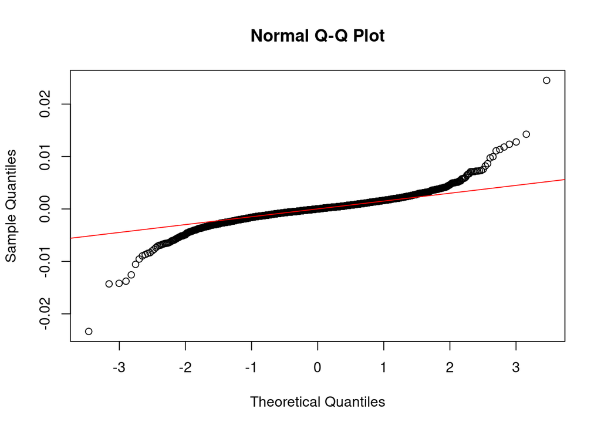

```r
qqnorm(residuals(model_semi_5))
qqline(residuals(model_semi_5), col = "red")
```

#Modelo Energía

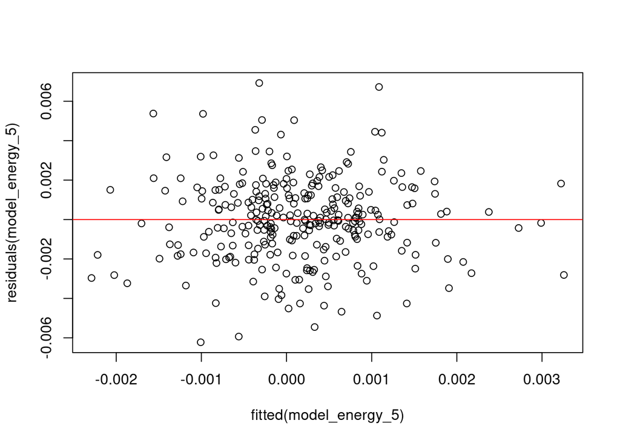

```r
plot(fitted(model_energy_5), residuals(model_energy_5))
abline(h = 0, col = "red")
```

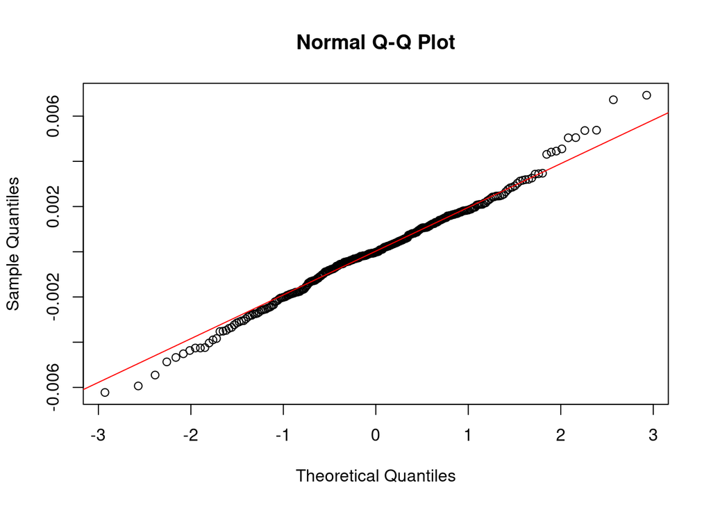

```r
qqnorm(residuals(model_energy_5))
qqline(residuals(model_energy_5), col = "red")
```

#PASO 9: MATRIZ DE CORRELACIÓN

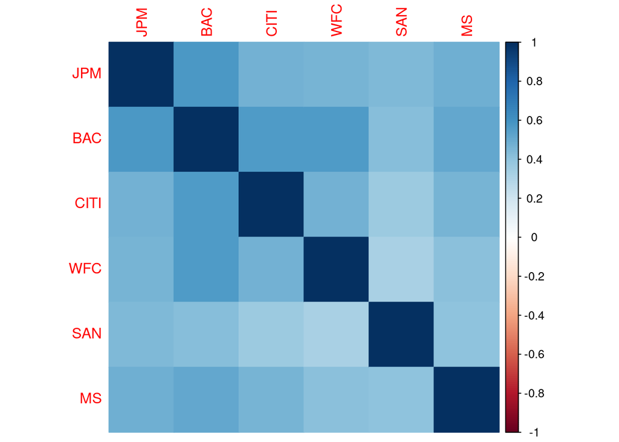

```r
# Bancario
cor_bank <- cor(bank_5 %>% select(-Date))
corrplot(cor_bank, method = "color")
```

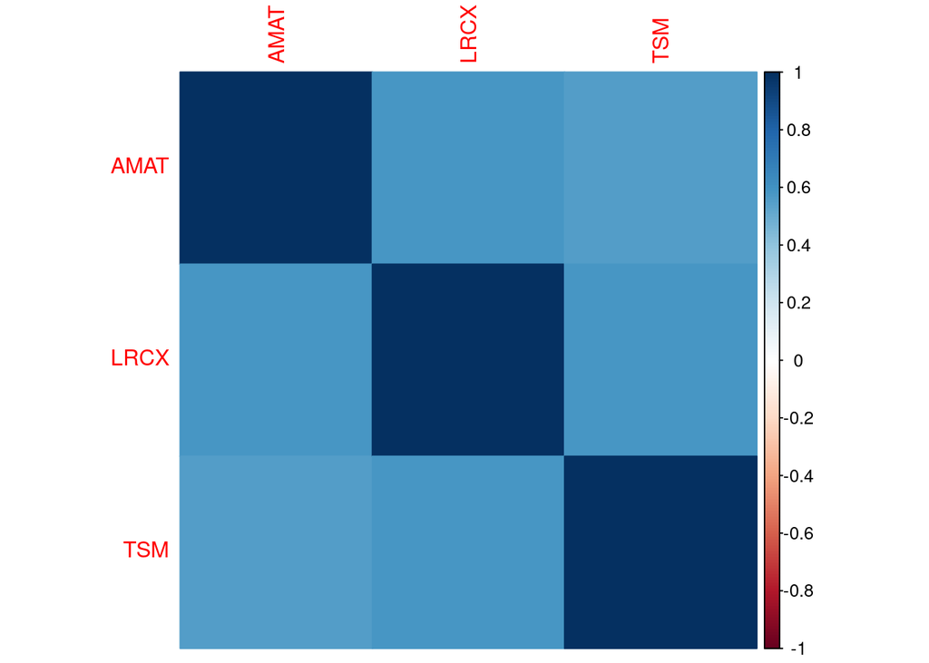

```r
# Semiconductores
cor_semi <- cor(semi_5 %>% select(-Date))
corrplot(cor_semi, method = "color")
```

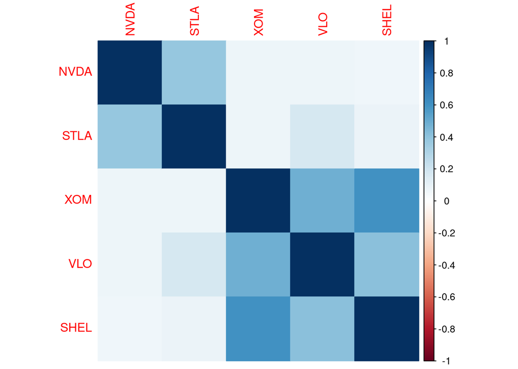

```r
# Energía
cor_energy <- cor(energy_5 %>% select(-Date))
corrplot(cor_energy, method = "color")
```

##PARTE 1: CÓDIGO DAILY (6 MESES)

#Definir archivos DAILY:

```r
# =========================
# ARCHIVOS DAILY (6 MESES)
# =========================

# Bancario
bank_files_d <- c("JPMDaily6Months.xlsx",
                  "BACDaily6Months.xlsx",
                  "CITIDaily6Months.xlsx",
                  "WFCDaily6Months.xlsx",
                  "SANDaily6Months.xlsx",
                  "MSDaily6Months.xlsx")

# Semiconductores
semi_files_d <- c("AMATDaily6Months.xlsx",
                  "LRCXDaily6Months.xlsx",
                  "TSMDaily6Months.xlsx")

# Energía
energy_files_d <- c("NVDADaily6Months.xlsx",
                    "STLADaily6Months.xlsx",
                    "XOMDaily6Months.xlsx",
                    "VLODaily6Months.xlsx",
                    "SHELDaily6Months.xlsx")
```

#PASO 1: GENERAR DATASETS DAILY

```r
# Bancario
bank_d   <- process_data(bank_files_d, bank_names, "date")

# Semiconductores
semi_d   <- process_data(semi_files_d, semi_names, "date")

# Energía
energy_d <- process_data(energy_files_d, energy_names, "date")
```

#PASO 2: MODELOS DAILY

```r
# Modelo 1: Bancario
model_bank_d <- lm(JPM ~ BAC + CITI + WFC + SAN + MS, data = bank_d)

# Modelo 2: Semiconductores
model_semi_d <- lm(AMAT ~ LRCX + TSM, data = semi_d)

# Modelo 3: Energía
model_energy_d <- lm(NVDA ~ STLA + XOM + VLO + SHEL, data = energy_d)
```

#PASO 3: RESULTADOS

```r
summary(model_bank_d)
```

```
##
## Call:
## lm(formula = JPM ~ BAC + CITI + WFC + SAN + MS, data = bank_d)
##
## Residuals:
##       Min        1Q    Median        3Q       Max
## -0.047495 -0.004467  0.000622  0.005652  0.024670
##
## Coefficients:
##               Estimate Std. Error t value Pr(>|t|)
## (Intercept) -0.0005795  0.0009219  -0.629  0.53090
## BAC          0.4232042  0.1281865   3.301  0.00129 **
## CITI         0.2249638  0.0970820   2.317  0.02231 *
## WFC         -0.0563153  0.1020301  -0.552  0.58208
## SAN          0.0393061  0.0510181   0.770  0.44266
## MS           0.1088515  0.0845147   1.288  0.20042
## ---
## Signif. codes:  0 '***' 0.001 '**' 0.01 '*' 0.05 '.' 0.1 ' ' 1
##
## Residual standard error: 0.009913 on 112 degrees of freedom
## Multiple R-squared:  0.5588, Adjusted R-squared:  0.5391
## F-statistic: 28.37 on 5 and 112 DF,  p-value: < 2.2e-16
```

```r
summary(model_semi_d)
```

```
##
## Call:
## lm(formula = AMAT ~ LRCX + TSM, data = semi_d)
##
## Residuals:
##       Min        1Q    Median        3Q       Max
## -0.031046 -0.008776 -0.001128  0.008422  0.065437
##
## Coefficients:
##             Estimate Std. Error t value Pr(>|t|)
## (Intercept) 0.001503   0.001332   1.128   0.2615
## LRCX        0.647961   0.057077  11.352   <2e-16 ***
## TSM         0.221410   0.085235   2.598   0.0106 *
## ---
## Signif. codes:  0 '***' 0.001 '**' 0.01 '*' 0.05 '.' 0.1 ' ' 1
##
## Residual standard error: 0.01463 on 120 degrees of freedom
## Multiple R-squared:  0.7647, Adjusted R-squared:  0.7608
## F-statistic:   195 on 2 and 120 DF,  p-value: < 2.2e-16
```

```r
summary(model_energy_d)
```

```
##
## Call:
## lm(formula = NVDA ~ STLA + XOM + VLO + SHEL, data = energy_d)
##
## Residuals:
##       Min        1Q    Median        3Q       Max
## -0.058409 -0.011785  0.000527  0.014422  0.057557
##
## Coefficients:
##               Estimate Std. Error t value Pr(>|t|)
## (Intercept)  0.0001899  0.0021228   0.089    0.929
## STLA        -0.0650285  0.0546663  -1.190    0.237
## XOM         -0.2841916  0.1818749  -1.563    0.121
## VLO          0.1312914  0.1046149   1.255    0.212
## SHEL         0.2842559  0.1824954   1.558    0.122
##
## Residual standard error: 0.02238 on 113 degrees of freedom
## Multiple R-squared:  0.04421,    Adjusted R-squared:  0.01038
## F-statistic: 1.307 on 4 and 113 DF,  p-value: 0.2718
```

#Validación de Supuestos del Modelo – Datos Diarios

#Multicolinealidad

```r
# Bancario
vif(model_bank_d)
```

```
##      BAC     CITI      WFC      SAN       MS
## 4.195674 3.978666 3.823129 1.135559 2.762685
```

```r
# Semiconductores
vif(model_semi_d)
```

```
##     LRCX      TSM
## 2.178409 2.178409
```

```r
# Energía
vif(model_energy_d)
```

```
##     STLA      XOM      VLO     SHEL
## 1.009794 1.652777 1.316542 1.306197
```

#Autocorrelación

```r
# Bancario
durbinWatsonTest(model_bank_d)
```

```
##  lag Autocorrelation D-W Statistic p-value
##    1      -0.2194987      2.437653   0.012
##  Alternative hypothesis: rho != 0
```

```r
bgtest(model_bank_d)
```

```
##
##  Breusch-Godfrey test for serial correlation of order up to 1
##
## data:  model_bank_d
## LM test = 6.0074, df = 1, p-value = 0.01425
```

```r
# Semiconductores
durbinWatsonTest(model_semi_d)
```

```
##  lag Autocorrelation D-W Statistic p-value
##    1     -0.04287936      2.083395   0.646
##  Alternative hypothesis: rho != 0
```

```r
bgtest(model_semi_d)
```

```
##
##  Breusch-Godfrey test for serial correlation of order up to 1
##
## data:  model_semi_d
## LM test = 0.23249, df = 1, p-value = 0.6297
```

```r
# Energía
durbinWatsonTest(model_energy_d)
```

```
##  lag Autocorrelation D-W Statistic p-value
##    1     0.005351968      1.987581   0.896
##  Alternative hypothesis: rho != 0
```

```r
bgtest(model_energy_d)
```

```
##
##  Breusch-Godfrey test for serial correlation of order up to 1
##
## data:  model_energy_d
## LM test = 0.0034473, df = 1, p-value = 0.9532
```

#Heterocedasticidad

```r
# Bancario
bptest(model_bank_d)
```

```
##
##  studentized Breusch-Pagan test
##
## data:  model_bank_d
## BP = 4.7263, df = 5, p-value = 0.4502
```

```r
gqtest(model_bank_d)
```

```
##
##  Goldfeld-Quandt test
##
## data:  model_bank_d
## GQ = 0.63206, df1 = 53, df2 = 53, p-value = 0.951
## alternative hypothesis: variance increases from segment 1 to 2
```

```r
# Semiconductores
bptest(model_semi_d)
```

```
##
##  studentized Breusch-Pagan test
##
## data:  model_semi_d
## BP = 0.56978, df = 2, p-value = 0.7521
```

```r
gqtest(model_semi_d)
```

```
##
##  Goldfeld-Quandt test
##
## data:  model_semi_d
## GQ = 1.008, df1 = 59, df2 = 58, p-value = 0.4882
## alternative hypothesis: variance increases from segment 1 to 2
```

```r
# Energía
bptest(model_energy_d)
```

```
##
##  studentized Breusch-Pagan test
##
## data:  model_energy_d
## BP = 8.0858, df = 4, p-value = 0.08849
```

```r
gqtest(model_energy_d)
```

```
##
##  Goldfeld-Quandt test
##
## data:  model_energy_d
## GQ = 0.83552, df1 = 54, df2 = 54, p-value = 0.7443
## alternative hypothesis: variance increases from segment 1 to 2
```

#Errores Robustos

```r
# Bancario
coeftest(model_bank_d, vcov = vcovHC(model_bank_d, type = "HC1"))
```

```
##
## t test of coefficients:
##
##                Estimate  Std. Error t value Pr(>|t|)
## (Intercept) -0.00057949  0.00088267 -0.6565 0.512838
## BAC          0.42320417  0.13977756  3.0277 0.003059 **
## CITI         0.22496376  0.09078671  2.4779 0.014707 *
## WFC         -0.05631529  0.18021409 -0.3125 0.755248
## SAN          0.03930614  0.05213767  0.7539 0.452496
## MS           0.10885151  0.11264814  0.9663 0.335978
## ---
## Signif. codes:  0 '***' 0.001 '**' 0.01 '*' 0.05 '.' 0.1 ' ' 1
```

```r
# Semiconductores
coeftest(model_semi_d, vcov = vcovHC(model_semi_d, type = "HC1"))
```

```
##
## t test of coefficients:
##
##              Estimate Std. Error t value  Pr(>|t|)
## (Intercept) 0.0015031  0.0013083  1.1489  0.252892
## LRCX        0.6479607  0.0543518 11.9216 < 2.2e-16 ***
## TSM         0.2214102  0.0755415  2.9310  0.004047 **
## ---
## Signif. codes:  0 '***' 0.001 '**' 0.01 '*' 0.05 '.' 0.1 ' ' 1
```

```r
# Energía
coeftest(model_energy_d, vcov = vcovHC(model_energy_d, type = "HC1"))
```

```
##
## t test of coefficients:
##
##                Estimate  Std. Error t value Pr(>|t|)
## (Intercept)  0.00018993  0.00208420  0.0911  0.92755
## STLA        -0.06502849  0.10357383 -0.6278  0.53137
## XOM         -0.28419161  0.15755039 -1.8038  0.07392 .
## VLO          0.13129142  0.09831626  1.3354  0.18443
## SHEL         0.28425588  0.15096206  1.8830  0.06228 .
## ---
## Signif. codes:  0 '***' 0.001 '**' 0.01 '*' 0.05 '.' 0.1 ' ' 1
```

#En esta sección se evalúan los supuestos clásicos del modelo de regresión lineal utilizando los modelos estimados con datos diarios, con el fin de validar la consistencia y confiabilidad de los resultados.

#Análisis de Residuos (Gráficas)

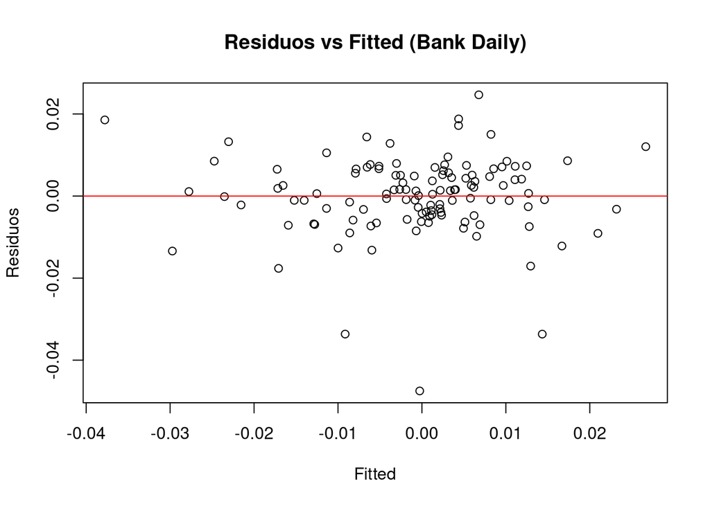

```r
# =========================
# BANCARIO
# =========================
plot(fitted(model_bank_d), residuals(model_bank_d),
     main = "Residuos vs Fitted (Bank Daily)",
     xlab = "Fitted", ylab = "Residuos")
abline(h = 0, col = "red")
```

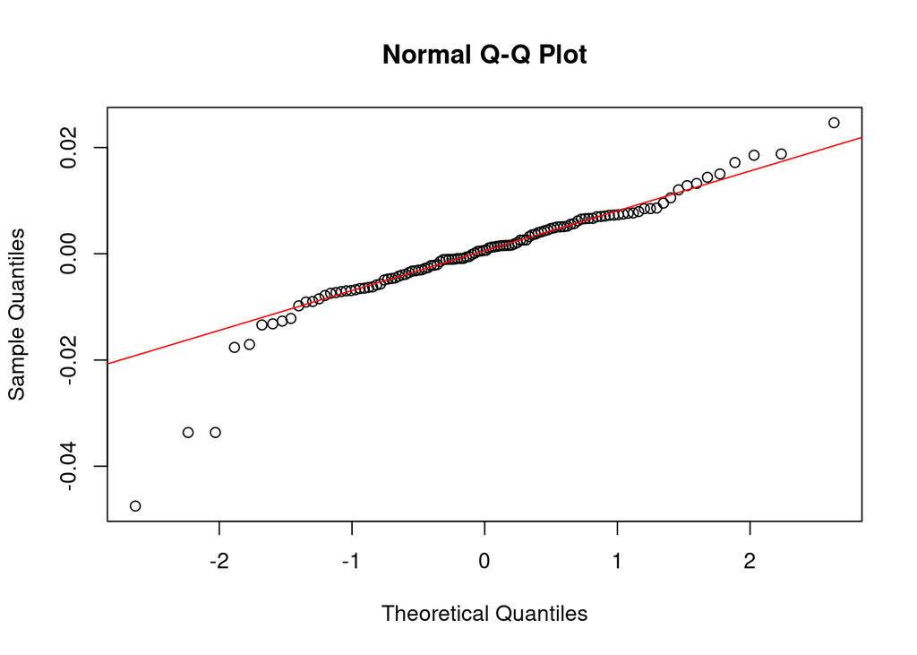

```r
qqnorm(residuals(model_bank_d))
qqline(residuals(model_bank_d), col = "red")
```

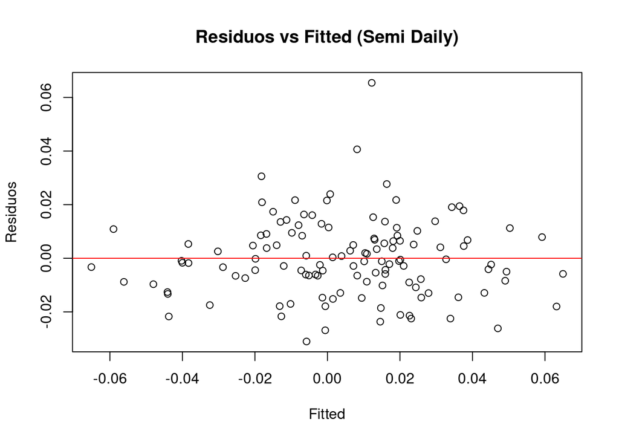

```r
# =========================
# SEMICONDUCTORES
# =========================
plot(fitted(model_semi_d), residuals(model_semi_d),
     main = "Residuos vs Fitted (Semi Daily)",
     xlab = "Fitted", ylab = "Residuos")
abline(h = 0, col = "red")
```

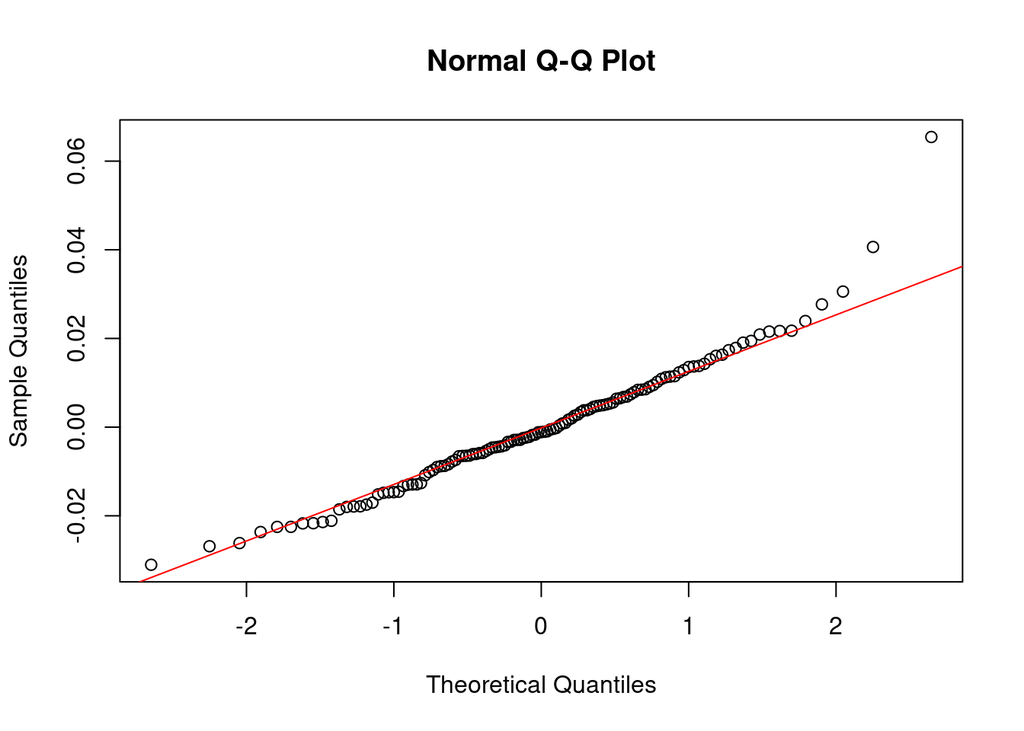

```r
qqnorm(residuals(model_semi_d))
qqline(residuals(model_semi_d), col = "red")
```

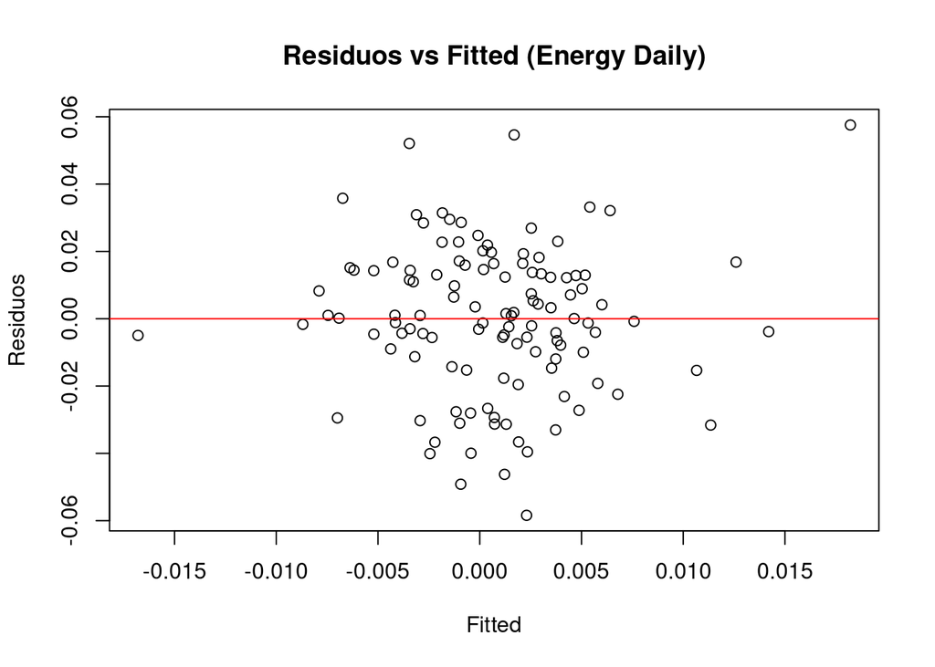

```r
# =========================
# ENERGÍA
# =========================
plot(fitted(model_energy_d), residuals(model_energy_d),
     main = "Residuos vs Fitted (Energy Daily)",
     xlab = "Fitted", ylab = "Residuos")
abline(h = 0, col = "red")
```

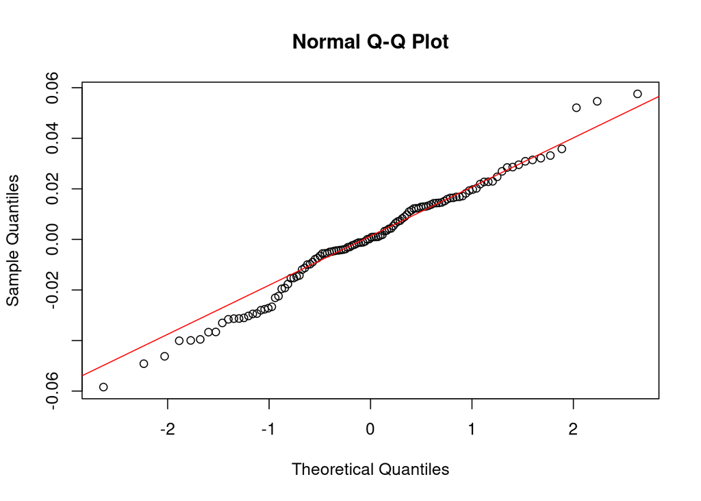

```r
qqnorm(residuals(model_energy_d))
qqline(residuals(model_energy_d), col = "red")
```

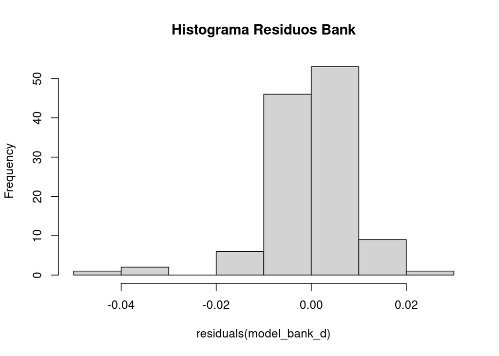

```r
hist(residuals(model_bank_d), main = "Histograma Residuos Bank")
```

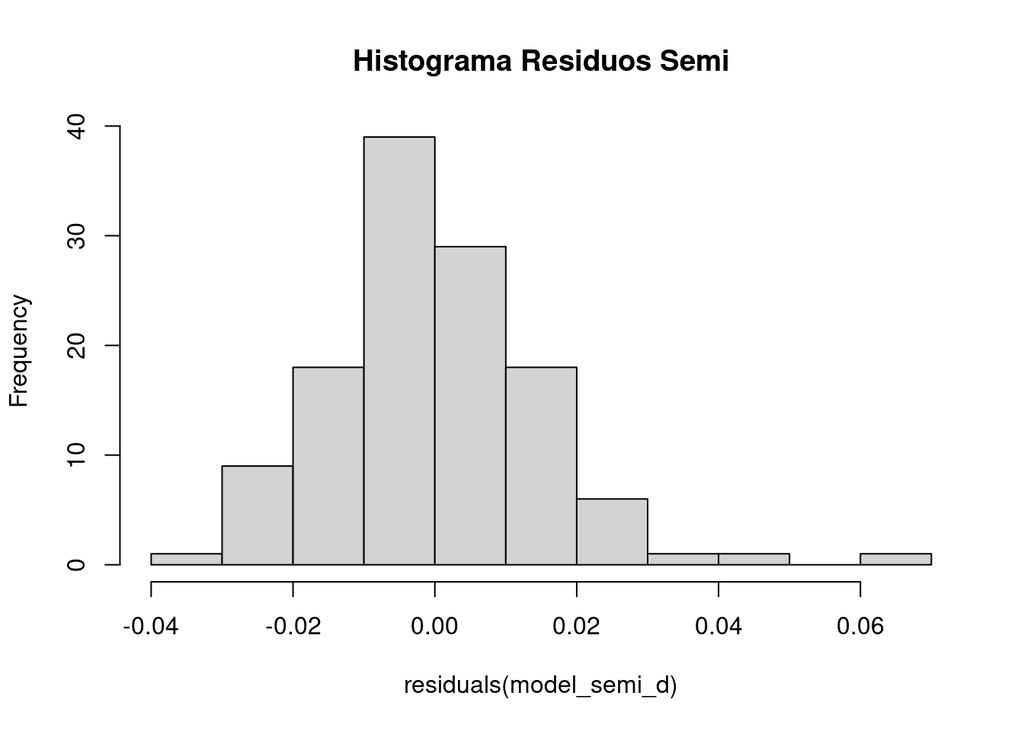

```r
hist(residuals(model_semi_d), main = "Histograma Residuos Semi")
```

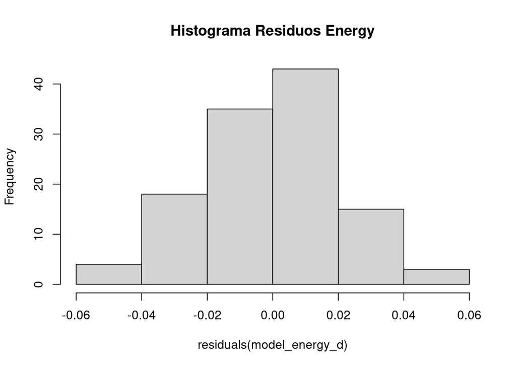

```r
hist(residuals(model_energy_d), main = "Histograma Residuos Energy")
```

#Regresiones Lineales Simples

```r
library(readxl)

jpm  <- read_excel("JPMDaily6Months.xlsx")
bac  <- read_excel("BACDaily6Months.xlsx")
citi <- read_excel("CITIDaily6Months.xlsx")
wfc  <- read_excel("WFCDaily6Months.xlsx")
san  <- read_excel("SANDaily6Months.xlsx")
ms   <- read_excel("MSDaily6Months.xlsx")

# =========================
# HACER MISMO TAMAÑO
# =========================
min_len <- min(
  nrow(jpm),
  nrow(bac),
  nrow(citi),
  nrow(wfc),
  nrow(san),
  nrow(ms)
)

# =========================
# CREAR DATASET
# =========================
data <- data.frame(
  JPM  = as.numeric(jpm$Close[1:min_len]),
  BAC  = as.numeric(bac$Close[1:min_len]),
  CITI = as.numeric(citi$Close[1:min_len]),
  WFC  = as.numeric(wfc$Close[1:min_len]),
  SAN  = as.numeric(san$Close[1:min_len]),
  MS   = as.numeric(ms$Close[1:min_len])
)

# =========================
# LIMPIAR
# =========================
data <- na.omit(data)

# =========================
# MODELOS
# =========================
model_bac  <- lm(JPM ~ BAC, data = data)
model_citi <- lm(JPM ~ CITI, data = data)
model_wfc  <- lm(JPM ~ WFC, data = data)
model_san  <- lm(JPM ~ SAN, data = data)
model_ms   <- lm(JPM ~ MS, data = data)

summary(model_bac)
```

```
##
## Call:
## lm(formula = JPM ~ BAC, data = data)
##
## Residuals:
##     Min      1Q  Median      3Q     Max
## -11.931  -3.668  -1.193   3.790  14.751
##
## Coefficients:
##             Estimate Std. Error t value Pr(>|t|)
## (Intercept)  92.5467    11.1819   8.276 1.85e-13 ***
## BAC           4.1071     0.2124  19.336  < 2e-16 ***
## ---
## Signif. codes:  0 '***' 0.001 '**' 0.01 '*' 0.05 '.' 0.1 ' ' 1
##
## Residual standard error: 5.27 on 122 degrees of freedom
## Multiple R-squared:  0.754,  Adjusted R-squared:  0.752
## F-statistic: 373.9 on 1 and 122 DF,  p-value: < 2.2e-16
```

```r
summary(model_citi)
```

```
##
## Call:
## lm(formula = JPM ~ CITI, data = data)
##
## Residuals:
##     Min      1Q  Median      3Q     Max
## -24.074  -5.705   1.366   7.404  17.282
##
## Coefficients:
##             Estimate Std. Error t value Pr(>|t|)
## (Intercept) 242.6446    11.3919  21.300  < 2e-16 ***
## CITI          0.6097     0.1051   5.803 5.27e-08 ***
## ---
## Signif. codes:  0 '***' 0.001 '**' 0.01 '*' 0.05 '.' 0.1 ' ' 1
##
## Residual standard error: 9.407 on 122 degrees of freedom
## Multiple R-squared:  0.2163, Adjusted R-squared:  0.2099
## F-statistic: 33.67 on 1 and 122 DF,  p-value: 5.271e-08
```

```r
summary(model_wfc)
```

```
##
## Call:
## lm(formula = JPM ~ WFC, data = data)
##
## Residuals:
##     Min      1Q  Median      3Q     Max
## -11.415  -4.769  -1.095   4.798  12.901
##
## Coefficients:
##             Estimate Std. Error t value Pr(>|t|)
## (Intercept) 162.6557     9.9138   16.41   <2e-16 ***
## WFC           1.6793     0.1139   14.74   <2e-16 ***
## ---
## Signif. codes:  0 '***' 0.001 '**' 0.01 '*' 0.05 '.' 0.1 ' ' 1
##
## Residual standard error: 6.371 on 122 degrees of freedom
## Multiple R-squared:  0.6405, Adjusted R-squared:  0.6375
## F-statistic: 217.3 on 1 and 122 DF,  p-value: < 2.2e-16
```

```r
summary(model_san)
```

```
##
## Call:
## lm(formula = JPM ~ SAN, data = data)
##
## Residuals:
##      Min       1Q   Median       3Q      Max
## -25.7063  -7.4022   0.3321   6.9799  24.5780
##
## Coefficients:
##             Estimate Std. Error t value Pr(>|t|)
## (Intercept)  284.082     11.252  25.248   <2e-16 ***
## SAN            2.541      1.164   2.183   0.0309 *
## ---
## Signif. codes:  0 '***' 0.001 '**' 0.01 '*' 0.05 '.' 0.1 ' ' 1
##
## Residual standard error: 10.42 on 122 degrees of freedom
## Multiple R-squared:  0.03761,    Adjusted R-squared:  0.02972
## F-statistic: 4.767 on 1 and 122 DF,  p-value: 0.03092
```

```r
summary(model_ms)
```

```
##
## Call:
## lm(formula = JPM ~ MS, data = data)
##
## Residuals:
##      Min       1Q   Median       3Q      Max
## -16.7101  -6.8289   0.7102   7.5451  15.7425
##
## Coefficients:
##              Estimate Std. Error t value Pr(>|t|)
## (Intercept) 209.87916   13.34573  15.726  < 2e-16 ***
## MS            0.58121    0.07846   7.408 1.84e-11 ***
## ---
## Signif. codes:  0 '***' 0.001 '**' 0.01 '*' 0.05 '.' 0.1 ' ' 1
##
## Residual standard error: 8.825 on 122 degrees of freedom
## Multiple R-squared:  0.3102, Adjusted R-squared:  0.3046
## F-statistic: 54.87 on 1 and 122 DF,  p-value: 1.841e-11
```